# Demographic Pyramids for Epidemiological Analysis

# 1 Demographic Pyramids for Epidemiological Analysis

## 1.1 Introduction

Today you will learn about the importance of using demographic pyramids to help visualize the distribution of a disease by age and sex and how to create one using `{ggplot2}`.

Let’s get into it!

## 1.2 Learning Objectives

By the end of this lesson, you will be able to:

- Explain **the importance of demographic pyramids** for communicating **age and sex-specific patterns** of disease distribution.
- Understand the **components of a demographic pyramid** and conceptualize it as a modified version of a **stacked bar plot**.
- **Summarize and prepare data** into the appropriate format for plotting with **{dplyr}** functions.
- Use **`{ggplot2}`** code to **plot a demographic pyramid using `geom_col()`**, showing total counts or percentages on the x axis.
- **Customize the plot** by changing the color scheme, labels, and axis.

## 1.3 Introducing Demographic Pyramids

‣ **Demographic pyramids** visualize population distribution by **age** and **sex**. ‣ These bar graphs divided down the center between male and female members of the population. ‣ Age groups on the y-axis and sex on the x-axis.

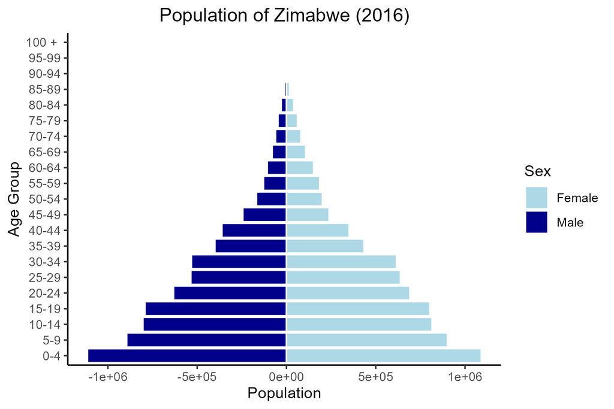

Population pyramid for a country with a young population has a pyramid-like shape.

‣ Three key features of a demographic pyramid are:

1. **Age Groups**: The pyramid is divided into horizontal bars, each representing an age group, often in five-year increments.
2. **Gender Representation**: The left side of the pyramid typically represents males, and the right side represents females.
3. **Population Size**: The length of the bars indicates the size of the population in each age group.

‣ `{ggplot2}` allows us to create and customize these pyramids.

## 1.4 Using Population Pyramids in Epidemiology

‣ Pyramids aid in understanding **age and gender-specific vulnerability** to different diseases.

‣ Incidence of diseases like **TB**, **HIV**, and **malaria** varies with age, sex, and differs by regions.

‣ These visualizations can inform **surveillance programs** about which age groups to target.

‣ **Demographic distribution** also assists in **data quality assessment** for routine surveillance by comparing national data with global epidemiology checks for **external consistency**.

## 1.5 Conceptualizing Demographic Pyramids

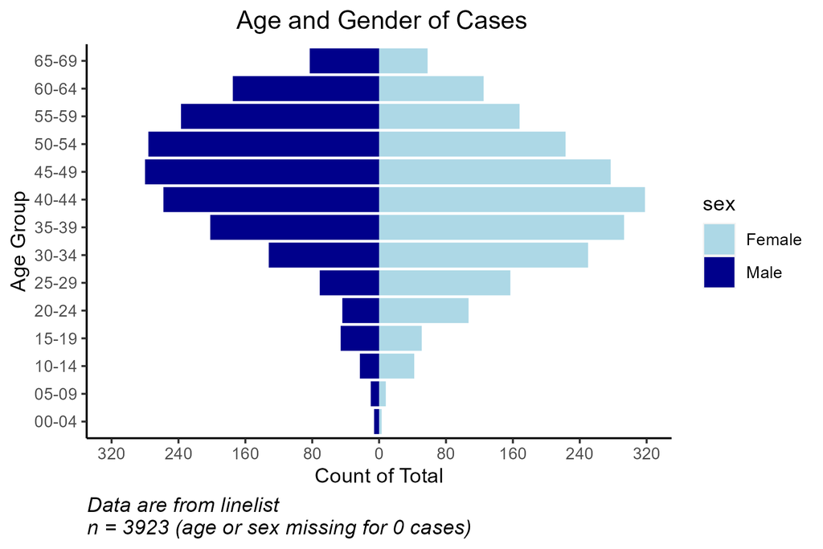

‣ A **population pyramid** is essentially two bar graphs merged on the y-axis.

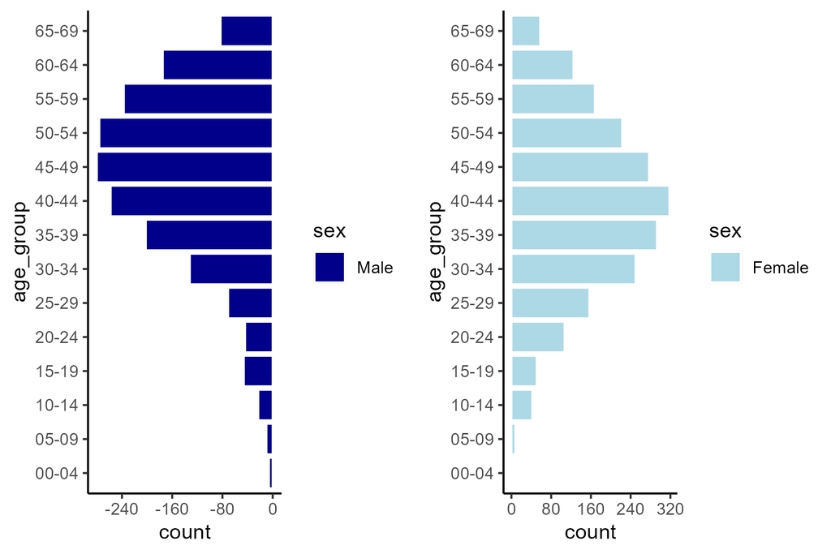

‣ Below is the female half of the pyramid, with axes flipped:

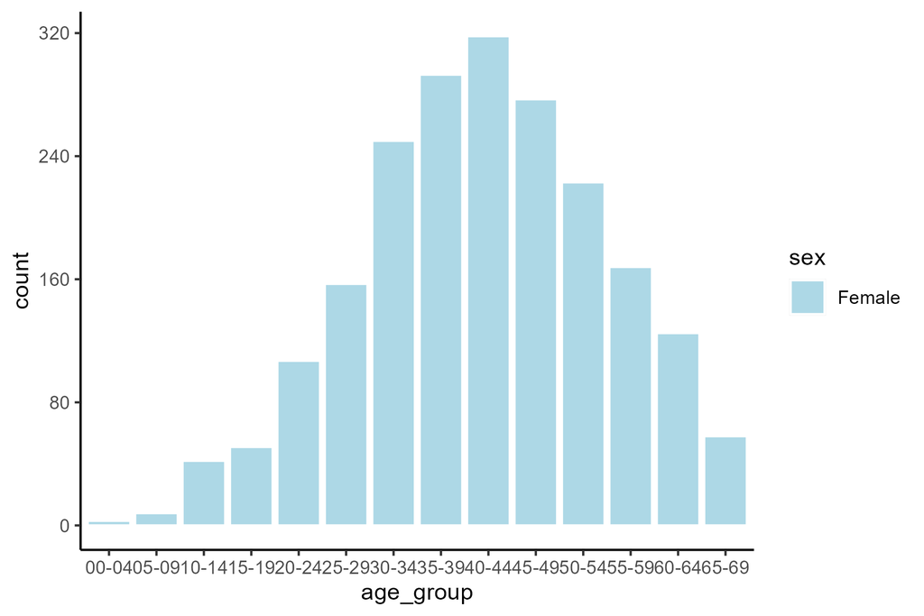

‣ We can also think of a demographic pyramid as akin to a modified stacked bar chart, with the bars centered at the point of division between the male and female sections.

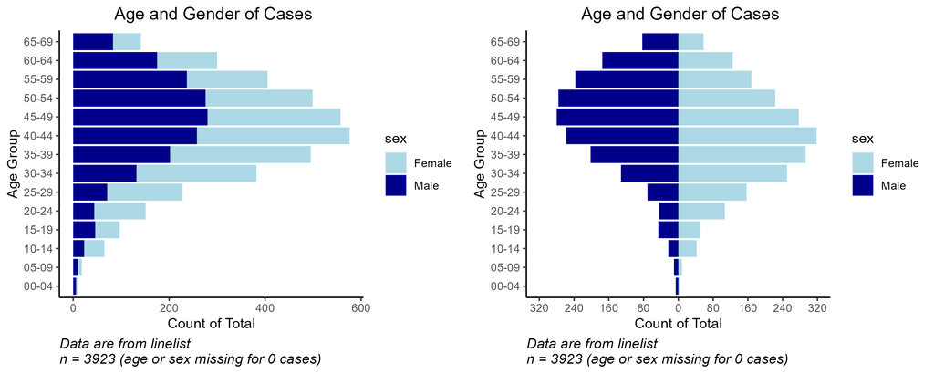

‣ To get this effect in `geom_col()`, we will calculate a **negative count** for males to plot the bars on the left side of the axis.